# Exercício 01 - R e Análise

### Perguntas a serem respondidas:

#### Temperatura:

```
1. Onde é mais quente?
2. Quais os meses mais quentes e mais frios?
```

#### Chuva:

```
1. No geral, onde chove mais?
2. A distribuição é diferente em meses específicos?
```

### Observando os dados:

```r
# lendo o arquivo csv com a biblioteca here
climas = read_csv(here::here("data/clima_cg_jp-semanal.csv"),
                  col_types = "cTdddddd")

glimpse(climas)
```

```
## Observations: 2,748
## Variables: 8
## $ cidade <chr> "Campina Grande", "Campina Grande", "Campina Grande", "Ca…
## $ semana <dttm> 1992-12-27, 1993-01-03, 1993-01-10, 1993-01-31, 1993-02-…
## $ tmedia <dbl> 26.13333, 26.11905, 25.76667, 25.74000, 26.31429, 26.2857…
## $ tmax   <dbl> 30.4, 32.4, 32.2, 32.0, 32.7, 32.7, 32.3, 32.3, 32.1, 31.…
## $ tmin   <dbl> 20.7, 19.3, 19.7, 19.9, 19.6, 20.0, 20.4, 21.2, 19.0, 19.…
## $ chuva  <dbl> 0.0, 0.0, 0.0, 0.4, 0.3, 0.0, 4.9, 0.0, 0.0, 6.1, 0.4, 1.…
## $ mes    <dbl> 12, 1, 1, 1, 2, 2, 2, 2, 10, 11, 11, 11, 11, 12, 12, 12, …
## $ ano    <dbl> 1992, 1993, 1993, 1993, 1993, 1993, 1993, 1993, 1993, 199…
```

Como pode ser visto acima, nossa base é formada por 2.748 instâncias de dados com 8 variáveis. As variáveis são: cidade (nesse caso Campina Grande e João Pessoa), semana, tmedia (temperatura média), tmax (temperatura máxima), tmin (temperatura máxima), chuva (pluviosidade), mes, e ano.

#### Sumário dos dados de Campina Grande:

```r
climas %>%
    filter(cidade == "Campina Grande") %>%
    summary()
```

```
##     cidade              semana                        tmedia
##  Length:1224        Min.   :1992-12-27 00:00:00   Min.   :20.77
##  Class :character   1st Qu.:2000-03-17 06:00:00   1st Qu.:23.52
##  Mode  :character   Median :2007-05-16 12:00:00   Median :25.00
##                     Mean   :2007-01-08 06:44:42   Mean   :24.69
##                     3rd Qu.:2013-03-25 18:00:00   3rd Qu.:25.87
##                     Max.   :2019-03-17 00:00:00   Max.   :28.57
##       tmax            tmin           chuva             mes
##  Min.   :25.00   Min.   :15.30   Min.   :  0.00   Min.   : 1.000
##  1st Qu.:28.70   1st Qu.:18.40   1st Qu.:  0.40   1st Qu.: 3.000
##  Median :30.70   Median :19.50   Median :  4.90   Median : 6.000
##  Mean   :30.32   Mean   :19.33   Mean   : 14.00   Mean   : 6.421
##  3rd Qu.:32.00   3rd Qu.:20.40   3rd Qu.: 18.65   3rd Qu.:10.000
##  Max.   :34.60   Max.   :22.60   Max.   :191.90   Max.   :12.000
##       ano
##  Min.   :1992
##  1st Qu.:2000
##  Median :2007
##  Mean   :2007
##  3rd Qu.:2013
##  Max.   :2019
```

#### Sumário dos dados de João Pessoa:

```r
climas %>%
    filter(cidade == "João Pessoa") %>%
    summary()
```

```
##     cidade              semana                        tmedia
##  Length:1524        Min.   :1987-12-27 00:00:00   Min.   :23.99
##  Class :character   1st Qu.:1997-04-04 06:00:00   1st Qu.:26.79
##  Mode  :character   Median :2004-08-11 12:00:00   Median :27.84
##                     Mean   :2004-07-03 04:55:44   Mean   :27.65
##                     3rd Qu.:2011-11-28 18:00:00   3rd Qu.:28.57
##                     Max.   :2019-03-17 00:00:00   Max.   :30.11
##       tmax            tmin          chuva             mes
##  Min.   :27.20   Min.   :15.6   Min.   :  0.00   Min.   : 1.000
##  1st Qu.:29.90   1st Qu.:21.3   1st Qu.:  3.00   1st Qu.: 3.000
##  Median :30.75   Median :22.6   Median : 14.10   Median : 7.000
##  Mean   :30.67   Mean   :22.5   Mean   : 32.65   Mean   : 6.507
##  3rd Qu.:31.40   3rd Qu.:23.7   3rd Qu.: 46.40   3rd Qu.:10.000
##  Max.   :33.70   Max.   :26.7   Max.   :351.60   Max.   :12.000
##       ano
##  Min.   :1987
##  1st Qu.:1997
##  Median :2004
##  Mean   :2004
##  3rd Qu.:2011
##  Max.   :2019
```

Foram exibidas novas informações sobre a base de dados. Temos 1.224 instâncias de dados sobre Campina Grande, sendo utilizados dados dos anos de 1992 até 2019. Já sobre os dados de João Pessoa, temos 1.524 instâncias, tendo dados de 1987 até 2019.

A partir dos sumários dos dados de cada cidade, é possível observar também as maiores e menores temperaturas registradas em cada cidade durante todo o período monitorado. A maior temperatura observada em Campina grande foi 34,6° C, enquanto a menor foi 15,3° C. Já em João Pessoa temos 33,7° como maior temperatura, e 15,6° como menor temperatura registrada.

# Preprocessamento dos dados:

Como há uma discrepância na quantidade de semanas monitoradas entre as duas cidades, para que não afete a visualização dos dados (principalmente na visualização de densidade) irei usar apenas as semanas onde existem os dados das duas cidades.

```r
semanas = climas %>% count(semana) %>% filter(n == 2) %>% pull(semana)


climasp = climas %>% filter(semana %in% semanas)

rm(climas) #apaga o dataframe que não será mais usado

glimpse(climasp)
```

```
## Observations: 2,430
## Variables: 8
## $ cidade <chr> "Campina Grande", "Campina Grande", "Campina Grande", "Ca…
## $ semana <dttm> 1992-12-27, 1993-01-03, 1993-01-10, 1993-01-31, 1993-02-…
## $ tmedia <dbl> 26.13333, 26.11905, 25.76667, 25.74000, 26.31429, 26.2857…
## $ tmax   <dbl> 30.4, 32.4, 32.2, 32.0, 32.7, 32.7, 32.3, 32.3, 32.1, 31.…
## $ tmin   <dbl> 20.7, 19.3, 19.7, 19.9, 19.6, 20.0, 20.4, 21.2, 19.0, 19.…
## $ chuva  <dbl> 0.0, 0.0, 0.0, 0.4, 0.3, 0.0, 4.9, 0.0, 0.0, 6.1, 0.4, 1.…
## $ mes    <dbl> 12, 1, 1, 1, 2, 2, 2, 2, 10, 11, 11, 11, 11, 12, 12, 12, …
## $ ano    <dbl> 1992, 1993, 1993, 1993, 1993, 1993, 1993, 1993, 1993, 199…
```

# Questões:

## Temperatura:

### Onde é mais quente?

Para responder a essa questão, achei melhor analisar não somente as temperaturas máximas de cada cidade (o que seria uma resolução simplista), mas também a frequência de semanas mais ou menos quentes durante todo o período monitorado.

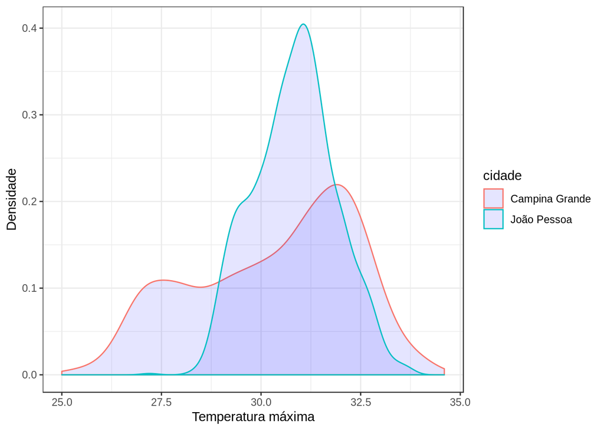

```r
ggplot(climasp, aes(tmax, colour = cidade)) +
  geom_density(fill = "blue", alpha = 0.1) +
  labs(x = "Temperatura máxima",
       y = "Densidade")
```

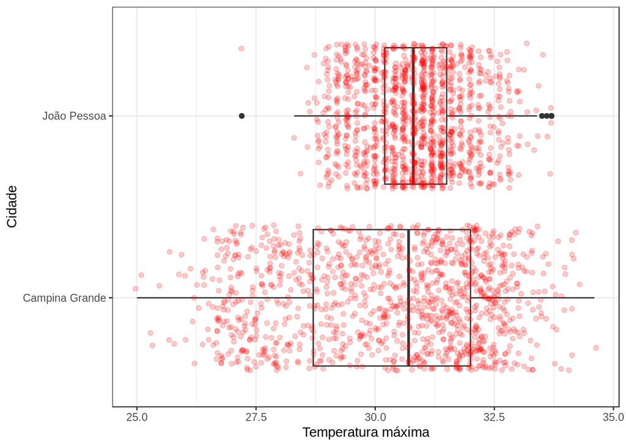

```r
ggplot(climasp, aes(x = cidade, y = tmax)) +
    geom_boxplot() +
    geom_jitter(color = "red", alpha = 0.2) +
    coord_flip() +
    labs(x = "Cidade",
       y = "Temperatura máxima")
```

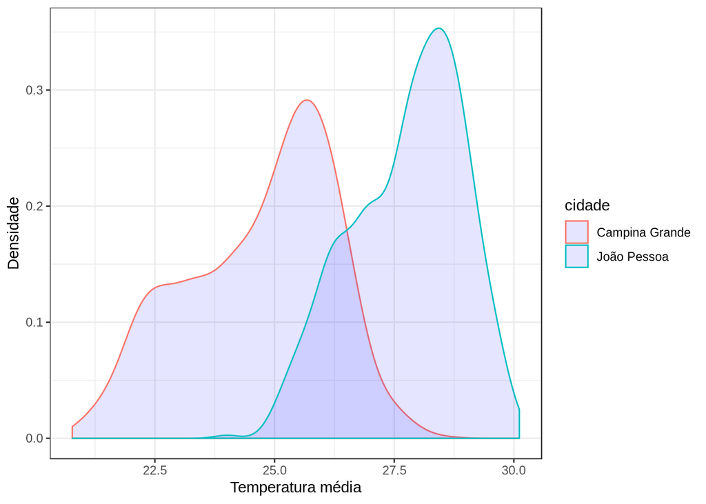

```r
ggplot(climasp, aes(tmedia, colour = cidade)) +
  geom_density(fill = "blue", alpha = 0.1) +
  labs(x = "Temperatura média",
       y = "Densidade")
```

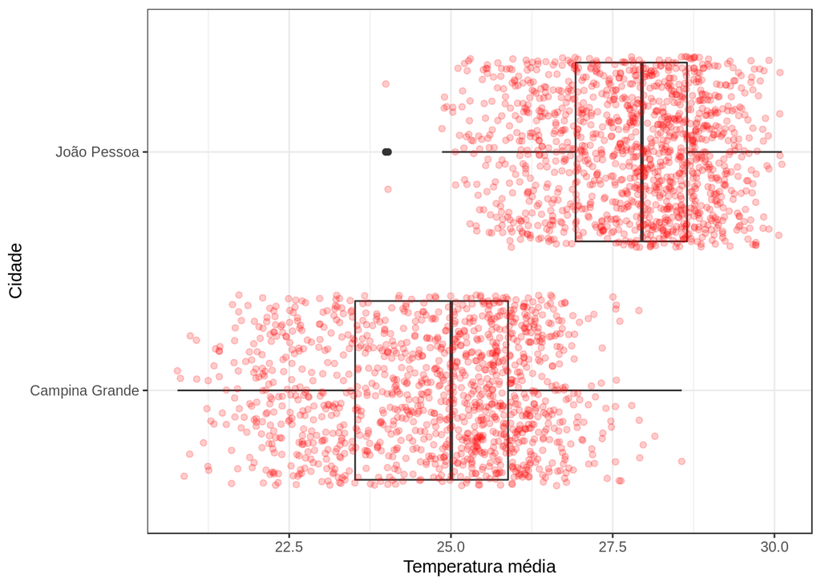

```r
ggplot(climasp, aes(x = cidade, y = tmedia)) +
    geom_boxplot() +
    geom_jitter(color = "red", alpha = 0.2) +
    coord_flip() +
    labs(x = "Cidade",
       y = "Temperatura média")
```

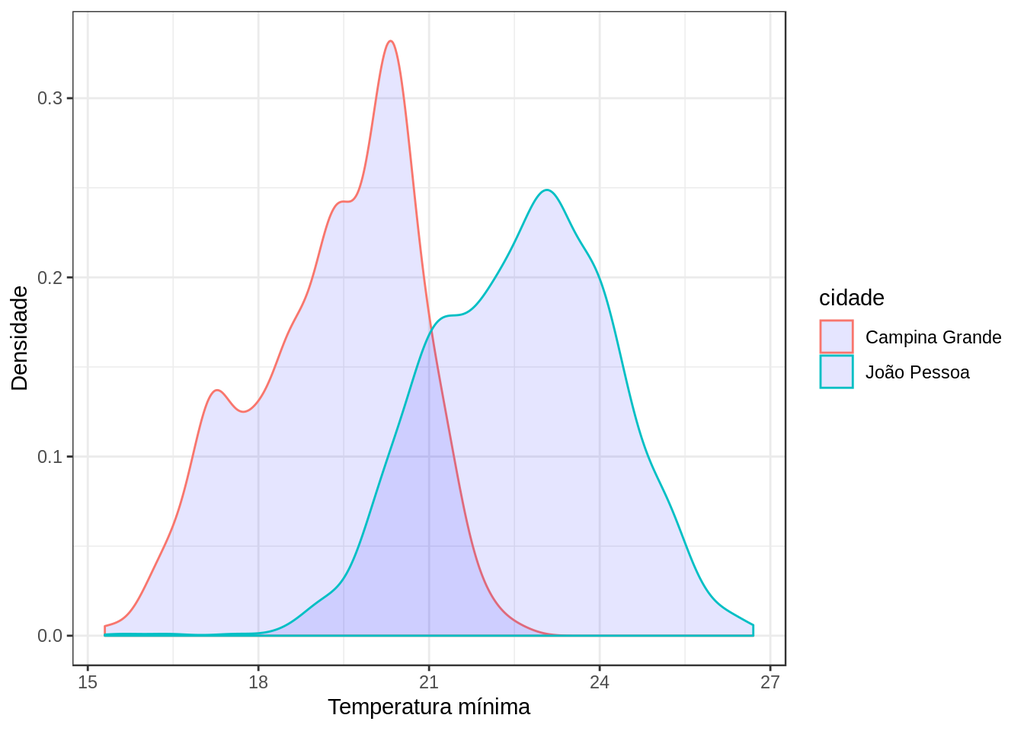

```r
ggplot(climasp, aes(tmin, colour = cidade)) +
  geom_density(fill = "blue", alpha = 0.1) +
  labs(x = "Temperatura mínima",
       y = "Densidade")
```

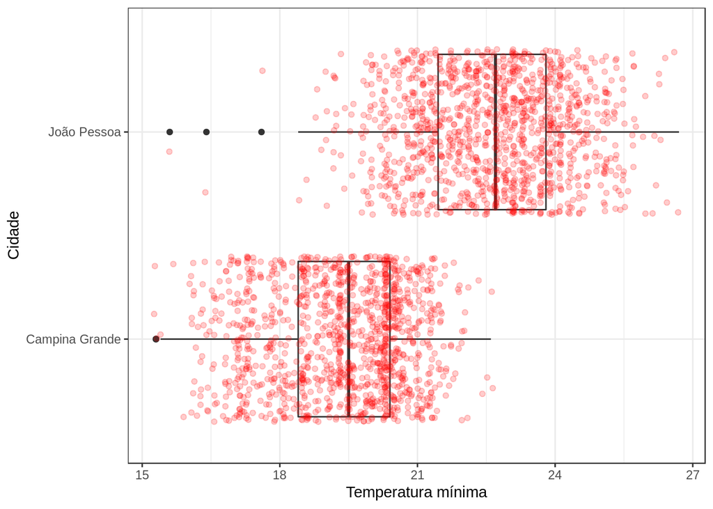

```r
ggplot(climasp, aes(x = cidade, y = tmin)) +
    geom_boxplot() +
    geom_jitter(color = "red", alpha = 0.2) +
    coord_flip() +
    labs(x = "Cidade",
       y = "Temperatura mínima")
```

### Quais o meses mais quente e mais frios?

```r
climacg = climasp %>%
    filter(cidade == "Campina Grande")

climajp = climasp %>%
    filter(cidade == "João Pessoa")
```

```r
climacg %>%
    group_by(mes) %>%
    summarise(media_mes_max = median(tmax), media_mes_media = median(tmedia), media_mes_min = median(tmin))
```

| mes | media_mes_max | media_mes_media | media_mes_min |
| --- | --- | --- | --- |
| 1 | 32.10 | 25.94286 | 20.4 |
| 2 | 32.05 | 25.94881 | 20.5 |
| 3 | 31.40 | 25.73810 | 20.6 |
| 4 | 30.70 | 25.26667 | 20.3 |
| 5 | 29.30 | 24.23333 | 19.5 |
| 6 | 27.50 | 22.79048 | 18.3 |
| 7 | 27.10 | 22.29286 | 17.2 |
| 8 | 27.90 | 22.67619 | 17.3 |
| 9 | 29.60 | 24.01905 | 18.1 |
| 10 | 31.20 | 25.10952 | 19.2 |

[output cut: 2 more lines]

```r
#    ggplot(aes(x = mes, y = media_mes_media)) +
#    geom_col(fill = "blue", alpha = 0.6) +
#    labs(y = "Média das temperatudas do mês",
#       x = "Mes")
```

```r
climajp %>%
    group_by(mes) %>%
    summarise(media_mes_max = median(tmax), media_mes_media = median(tmedia), media_mes_min = median(tmin))
```

| mes | media_mes_max | media_mes_media | media_mes_min |
| --- | --- | --- | --- |
| 1 | 31.4 | 28.65238 | 23.60 |
| 2 | 31.6 | 28.82857 | 23.60 |
| 3 | 31.8 | 29.02381 | 23.70 |
| 4 | 31.4 | 28.36190 | 23.10 |
| 5 | 31.0 | 27.64762 | 22.50 |
| 6 | 30.0 | 26.36190 | 21.30 |
| 7 | 29.4 | 26.05714 | 20.95 |
| 8 | 29.4 | 26.35714 | 20.70 |
| 9 | 30.0 | 27.04762 | 21.50 |
| 10 | 30.6 | 27.81905 | 22.90 |

[output cut: 2 more lines]

Os meses mais quentes nas duas cidades são: Dezembro, Janeiro, Fevereiro, e Março. Já os mais frios são: Junho, Julho, Agosto, e Setembro.

```r
rm("climacg")
rm("climajp")
```

## Chuva

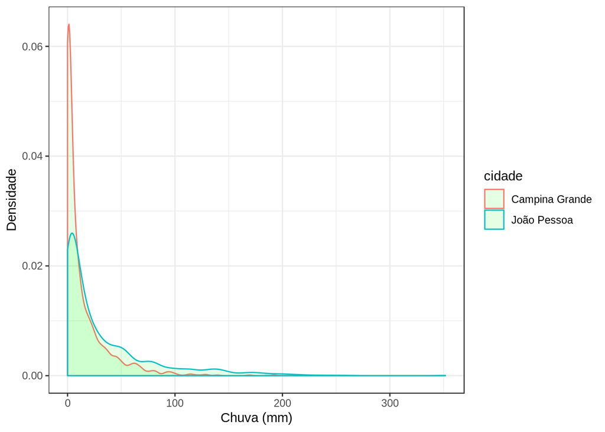

```r
climasp %>%
  ggplot(aes(chuva, colour = cidade)) +
  geom_density(fill = "green", alpha = 0.1) +
  labs(x = "Chuva (mm)",
       y = "Densidade")
```

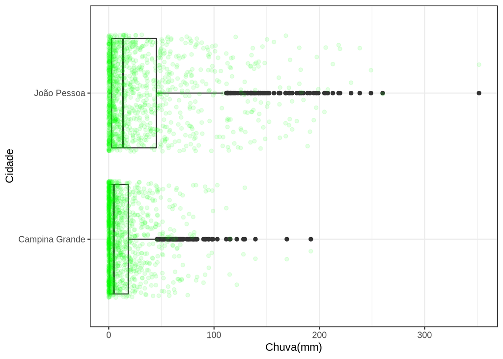

```r
climasp %>%
  ggplot(aes(x = cidade, y = chuva)) +
  geom_boxplot() +
  coord_flip() +
  geom_jitter(color = "green", alpha = 0.1) +
  labs(x = "Cidade",
       y = "Chuva(mm)")
```

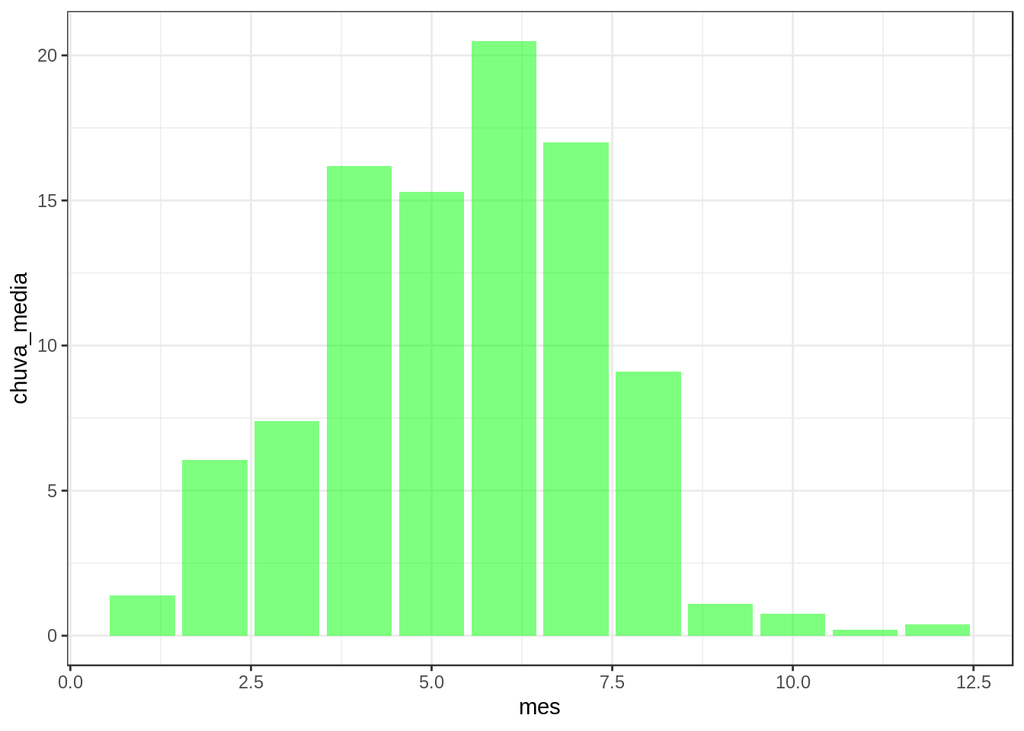

```r
climasp %>%
  filter(cidade == "Campina Grande") %>%
  group_by(mes) %>%
  summarise(chuva_media = median(chuva)) %>%
  ggplot(aes(x = mes, y = chuva_media)) +
  geom_col(fill = "green", alpha = 0.5)
```

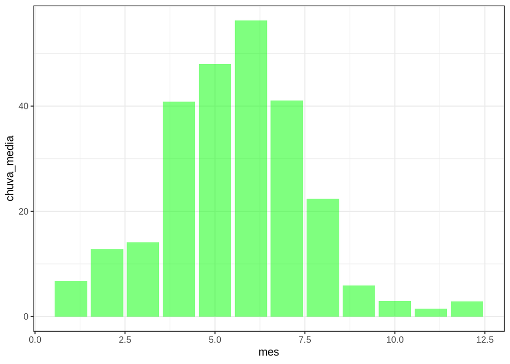

```r
climasp %>%
  filter(cidade == "João Pessoa") %>%
  group_by(mes) %>%
  summarise(chuva_media = median(chuva)) %>%
  ggplot(aes(x = mes, y = chuva_media)) +
  geom_col(fill = "green", alpha = 0.5)
```

#### No geral, onde chove mais?

Os gráficos de densidade, variação e da média de chuva dos meses dizem que chova mais em João Pessoa. Em Campina Grande há menos constância nos períodos de chuva, ocorrendo alguns picos em determinados meses. Mas mesmo assim, os períodos de chuva de João Pessoa são mais consistentes, e com maior volume de chuva.

#### A distribuição é diferente em meses específicos?

Os gráficos de média de chuva em relação aos meses mostram uma certa simetria. O ano começa e termina com baixo volume de chuva, ao se aproximar da metade do ano o volume vai aumentando, e encontra seu ápice em Junho, onde começa o inverno.